# Import data and packages to complete analysis of dataset detailing the factors important in the survivorship of passengers aboard the Titanic

```python
# Load packages, setup notebook to display plots
import matplotlib.pyplot as plt
import matplotlib.mlab as mlab
import numpy as np
import scipy.stats as stats
import pandas as pd
import seaborn as sns
import math
import statsmodels.api as sm
from statsmodels.graphics.api import abline_plot
from statsmodels import graphics
from statsmodels.formula.api import ols, glm, logit
import statsmodels.formula.api as smf
%matplotlib inline

# Read in data
csv = 'titanic_data.csv'
titanic_df = pd.read_csv(csv)

# Print first few lines of df
if False:
    print titanic_df.head()
    print len(titanic_df)
```

## Clean up data

```python
# Iterate through columns to count the number of missing values in each column, then print out the number of missing values.
col_names = list(titanic_df.columns.values)
for column in col_names:
    val = -titanic_df[column].count() + titanic_df['PassengerId'].count()
    if val > 0:
        print "\n The number of values missing from the ",column," column is: ",val
```

```
 The number of values missing from the  Age  column is:  177

 The number of values missing from the  Cabin  column is:  687

 The number of values missing from the  Embarked  column is:  2
```

Any analysis involving passenger age or point of embarkation will require some cleaning - my gut tells me that the best way to do this is to remove the values (age is missing 177 values, embarked is missing 2 values). I am not interested in the cabin numbers, so I will leave these alone. For point of embarkation it could be possible to examine surnames and attempt to infer a point of embarkation, but this would require making some assumptions about the data set that probably shouldn't be made. So from this point onwards, I will create data sets that have: all rows with missing ages removed; and another with all rows missing a point of embarkation removed.

### Make some new, clean data frames

```python
# Start by making a data frame which removes all of the rows where age is NaN
clean_age_df = titanic_df.dropna(subset=["Age"]).copy()

# Start by making a data frame which removes all of the rows where embarked is NaN
clean_embark_df = titanic_df.dropna(subset = ["Embarked"]).copy()

# Start by making a data frame which removes all of the rows where age and embarked is NaN
clean_age_embark_df = titanic_df.dropna().copy()
```

# Question 1: How does survivorship vary with age?

## Perform a logistic regression on survivorship as a function of age

```python
# Create new data set that comprises the age and survived columns
cols_to_keep = ['Survived','Age']
age_data = clean_age_df[cols_to_keep].copy()

# Add an intercept column so that the logistic regression estimates an intercept
age_data['Intercept'] = 1.0
#print age_data.head()
```

## Start simple with a model of survivorship as a function of only age

```
   Survived   Age  Intercept
1         1  38.0        1.0
2         1  26.0        1.0
3         1  35.0        1.0
8         1  27.0        1.0
9         1  14.0        1.0
28.3436896552 14.9509519841
30.6261792453 14.1721098771
```

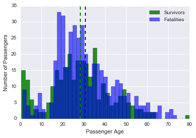

```python
# Visualize the distribution of ages for survivors and fatalities first
survived_age = age_data[age_data['Survived']==1]
died_age = age_data[age_data['Survived']==0]

print survived_age.head()
# Calculate mean ages of survivors and fatalities
mu_s_age = np.mean(survived_age['Age'])
std_s_age = np.std(survived_age['Age'],ddof=1)
print mu_s_age,std_s_age
mu_d_age = np.mean(died_age['Age'])
std_d_age = np.std(died_age['Age'],ddof=1)
print mu_d_age,std_d_age

# Plot histogram and vertical line corresponding with the mean age for the surviving or fatality group
n2,bins2,patches2 = plt.hist(survived_age['Age'],40,facecolor='green',alpha=.85,label='Survivors')
plt.axvline(mu_s_age, color='green', linestyle='dashed', linewidth=2)
plt.xlim([0,80])
n3,bins3,patches3 = plt.hist(died_age['Age'],40,facecolor='blue',alpha=.6,label='Fatalities')
plt.axvline(mu_d_age, color='blue', linestyle='dashed', linewidth=2)

plt.xlabel("Passenger Age")
plt.ylabel("Number of Passengers")
plt.grid(True)
plt.legend()
plt.show()
#plt.savefig('simpleagedist.png')
```

```
                 Generalized Linear Model Regression Results
==============================================================================
Dep. Variable:               Survived   No. Observations:                  714
Model:                            GLM   Df Residuals:                      712
Model Family:                Binomial   Df Model:                            1
Link Function:                  logit   Scale:                             1.0
Method:                          IRLS   Log-Likelihood:                -480.11
Date:                Sat, 29 Oct 2016   Deviance:                       960.23
Time:                        15:06:22   Pearson chi2:                     714.
No. Iterations:                     6
==============================================================================
                 coef    std err          z      P>|z|      [95.0% Conf. Int.]
------------------------------------------------------------------------------
Age           -0.0110      0.005     -2.057      0.040        -0.021    -0.001
Intercept     -0.0567      0.174     -0.327      0.744        -0.397     0.283
==============================================================================
Optimization terminated successfully.
         Current function value: 0.672429
         Iterations 4
                           Logit Regression Results
==============================================================================
Dep. Variable:               Survived   No. Observations:                  714
Model:                          Logit   Df Residuals:                      712
Method:                           MLE   Df Model:                            1
Date:                Sat, 29 Oct 2016   Pseudo R-squ.:                0.004445
Time:                        15:06:22   Log-Likelihood:                -480.11
converged:                       True   LL-Null:                       -482.26
                                        LLR p-value:                   0.03839
==============================================================================
                 coef    std err          z      P>|z|      [95.0% Conf. Int.]
------------------------------------------------------------------------------
Intercept     -0.0567      0.174     -0.327      0.744        -0.397     0.283
Age           -0.0110      0.005     -2.057      0.040        -0.021    -0.001
==============================================================================
Age          0.989096
Intercept    0.944855
dtype: float64
```

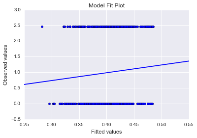

```python
# Run a logistic regression using the GLM function and specifying the binomial family
# Note: this regression is of the Survived variable on age, an intercept is also being estimated
age_only_train = age_data.columns[[1,2]]
age_logit = sm.GLM(age_data['Survived'], age_data[age_only_train], family=sm.families.Binomial())
result = age_logit.fit()
print result.summary()

age_only = logit(formula = 'Survived ~ Age',data =age_data).fit()
print age_only.summary()

# Plot fit of the model
nobs = result.nobs
y =  clean_age_df['Survived']/ clean_age_df['Survived'].mean()
yhat = result.mu
fig, ax = plt.subplots()
ax.scatter(yhat, y)
line_fit = sm.OLS(y, sm.add_constant(yhat, prepend=True)).fit()
abline_plot(model_results=line_fit,ax=ax)
ax.set_title('Model Fit Plot')
ax.set_ylabel('Observed values')
ax.set_xlabel('Fitted values')

# output odds ratios
print np.exp(result.params)
```

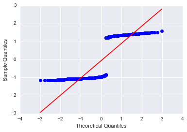

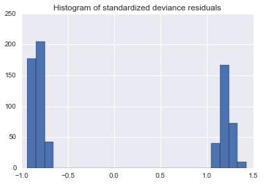

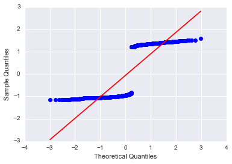

```python
# Generate a plot that shows the fit of the standardized residuals to the binomial distribution
fig, ax = plt.subplots()

resid = result.resid_deviance.copy()
resid_std = stats.zscore(resid)
ax.hist(resid_std, bins=25)
ax.set_title('Histogram of standardized deviance residuals');
graphics.gofplots.qqplot(resid, line='r')
```

Here we see that while the age effect is statistically significant, the model does not explain much of the variation in the data set. We will need to consider more complex models to see if there is a better way to explain survivorship than with age alone.

#### Compare the probability of survival of the very old and very young to everyone else

```python
def age_class(row):
    if row['Age'] <= 15:
        val = 'child'
    elif row['Age'] > 15 and row['Age'] <= 45:
        val = 'adult'
    else:
        val = 'senior'
    return val

age_data['Age_class'] = age_data.apply(age_class,axis=1)
#print age_data.head()

# perform contrasts comparing male and female survivors
from patsy.contrasts import Treatment
levels = [1,2,3]
contrast = Treatment(reference=0).code_without_intercept(levels)
print age_data.groupby('Age_class')['Survived'].mean()
print contrast.matrix

c_age = ols('Survived ~ C(Age_class,Treatment)',data=age_data)
res_c_age = c_age.fit()
print(res_c_age.summary())
```

```
Age_class
adult     0.384470
child     0.590361
senior    0.368932
Name: Survived, dtype: float64
[[ 0.  0.]
 [ 1.  0.]
 [ 0.  1.]]
                            OLS Regression Results
==============================================================================
Dep. Variable:               Survived   R-squared:                       0.019
Model:                            OLS   Adj. R-squared:                  0.016
Method:                 Least Squares   F-statistic:                     6.747
Date:                Sat, 29 Oct 2016   Prob (F-statistic):            0.00125
Time:                        15:06:25   Log-Likelihood:                -498.70
No. Observations:                 714   AIC:                             1003.
Df Residuals:                     711   BIC:                             1017.
Df Model:                           2
Covariance Type:            nonrobust
=====================================================================================================
                                        coef    std err          t      P>|t|      [95.0% Conf. Int.]
-----------------------------------------------------------------------------------------------------
Intercept                             0.3845      0.021     18.120      0.000         0.343     0.426
C(Age_class, Treatment)[T.child]      0.2059      0.058      3.577      0.000         0.093     0.319
C(Age_class, Treatment)[T.senior]    -0.0155      0.053     -0.296      0.767        -0.119     0.088
==============================================================================
Omnibus:                       16.714   Durbin-Watson:                   1.917
Prob(Omnibus):                  0.000   Jarque-Bera (JB):              111.289
Skew:                           0.383   Prob(JB):                     6.82e-25
Kurtosis:                       1.224   Cond. No.                         3.39
==============================================================================

Warnings:
[1] Standard Errors assume that the covariance matrix of the errors is correctly specified.
```

## Look at the influence of age and sex on survivorship

```python
# Create new data set that comprises the age, sex and survived columns
cols_to_keep = ['Survived','Age','Sex']
agesex_data = clean_age_df[cols_to_keep].copy()

# Add an intercept column so that the logistic regression estimates an intercept
agesex_data['Intercept'] = 1.0

# Do some exploratory analysis
# Visualize the distribution of ages for surviving men and women
survived_age = agesex_data[agesex_data['Survived']==1]
died_age = agesex_data[agesex_data['Survived']==0]

surv_men = survived_age[survived_age['Sex']=='male']
dead_men = died_age[died_age['Sex']=='male']
surv_women = survived_age[survived_age['Sex']=='female']
dead_women = died_age[died_age['Sex']=='female']

# Look at the gender ratio
num_men = surv_men['Age'].count() + dead_men['Age'].count()
num_women = surv_women['Age'].count() + dead_women['Age'].count()
print "Gender ratio (proportion of men) of passengers",float(num_men)/(num_women + num_men)

# Look at gender ratio of survivors
num_s_men = surv_men['Age'].count()
num_s_women = surv_women['Age'].count()
print "Gender ratio of survivors: ",float(num_s_men)/(num_s_women + num_s_men)

# Calculate mean ages of survivors and fatalities of each sex
mu_sm_age = np.mean(surv_men['Age'])
std_sm_age = np.std(surv_men['Age'],ddof=1)
print "Mean age of male survivors:", mu_sm_age,"Std:",std_sm_age
mu_dm_age = np.mean(dead_men['Age'])
std_dm_age = np.std(dead_men['Age'],ddof=1)
print "Mean age of male fatalities:",mu_dm_age,"Std:",std_dm_age

mu_sw_age = np.mean(surv_women['Age'])
std_sw_age = np.std(surv_women['Age'],ddof=1)
print "Mean age of female survivors:", mu_sw_age,"Std:",std_sw_age
mu_dw_age = np.mean(dead_women['Age'])
std_dw_age = np.std(dead_women['Age'],ddof=1)
print "Mean age of female fatalities:",mu_dw_age,"Std:",std_dw_age
```

```
Gender ratio (proportion of men) of passengers 0.634453781513
Gender ratio of survivors:  0.320689655172
Mean age of male survivors: 27.2760215054 Std: 16.5048029992
Mean age of male fatalities: 31.6180555556 Std: 14.0560193035
Mean age of female survivors: 28.847715736 Std: 14.1750727011
Mean age of female fatalities: 25.046875 Std: 13.6185910367
```

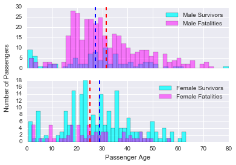

```python
# Three subplots sharing both x/y axes
f, (ax1, ax2) = plt.subplots(2, sharex=True,)

# Plot histogram and vertical line corresponding with the mean age for the surviving or fatality group
# Surviving men
ax1.hist(surv_men['Age'],40,facecolor='cyan',alpha=.75,label='Male Survivors')
ax1.axvline(mu_sm_age, color='blue', linestyle='dashed', linewidth=2)
# Dead men
ax1.hist(dead_men['Age'],40,facecolor='magenta',alpha=.5,label='Male Fatalities')
ax1.axvline(mu_dm_age, color='red', linestyle='dashed', linewidth=2)
ax1.legend()

# Surviving women
ax2.hist(surv_women['Age'],40,facecolor='cyan',alpha=.75,label='Female Survivors')
ax2.axvline(mu_sw_age, color='blue', linestyle='dashed', linewidth=2)
# Dead men
ax2.hist(dead_women['Age'],40,facecolor='magenta',alpha=.5,label='Female Fatalities')
ax2.axvline(mu_dw_age, color='red', linestyle='dashed', linewidth=2)

plt.xlabel("Passenger Age")
plt.ylabel("Number of Passengers")
plt.grid(True)
ax2.legend()

ax2.yaxis.set_label_coords(-.08, 1.05)

plt.show()
```

```python
# Create a dummy variable for the sex variable
dummy_ranks_sex = pd.get_dummies(clean_age_df['Sex'],prefix='Sex')
dummy_ranks_sex = dummy_ranks_sex.astype(int)
#print dummy_ranks_sex.head()

# Add the intercept to the starting clean df
clean_age_df['Intercept'] = 1.0
#print clean_age_df.head()

# Create new data set that joins the dummy variable to the relevant variables for the analysis
cols_to_keep2 = ['Survived','Age','Intercept']
agesex_data = clean_age_df[cols_to_keep2].join(dummy_ranks_sex.ix[:,'Sex_male':])
#print agesex_data.head()
```

```
Optimization terminated successfully.
         Current function value: 0.518490
         Iterations 6
                           Logit Regression Results
==============================================================================
Dep. Variable:               Survived   No. Observations:                  714
Model:                          Logit   Df Residuals:                      710
Method:                           MLE   Df Model:                            3
Date:                Sat, 29 Oct 2016   Pseudo R-squ.:                  0.2324
Time:                        15:06:28   Log-Likelihood:                -370.20
converged:                       True   LL-Null:                       -482.26
                                        LLR p-value:                 2.592e-48
================================================================================
                   coef    std err          z      P>|z|      [95.0% Conf. Int.]
--------------------------------------------------------------------------------
Intercept        0.5938      0.310      1.913      0.056        -0.014     1.202
Age              0.0197      0.011      1.863      0.062        -0.001     0.040
Sex_male        -1.3178      0.408     -3.226      0.001        -2.118    -0.517
Age:Sex_male    -0.0411      0.014     -3.034      0.002        -0.068    -0.015
================================================================================
Intercept       1.810858
Age             1.019897
Sex_male        0.267737
Age:Sex_male    0.959715
dtype: float64
```

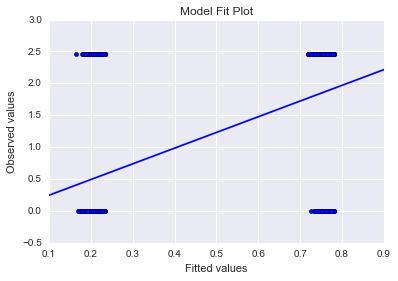

```python
# Run a full logistic regression model including the interaction between age and sex
agesex_train = agesex_data.columns[[1,2,3]]
agesex_logit = sm.GLM(agesex_data['Survived'], agesex_data[agesex_train], family=sm.families.Binomial()).fit()
#print agesex_logit.summary()
male_int = logit(formula = 'Survived ~ Age + Sex_male + Age*Sex_male',data =agesex_data).fit()
print male_int.summary()

# output odds ratios for this full model
print np.exp(male_int.params)

#Print some diagnostic plots to assess model fit
nobs_ans = agesex_logit.nobs

y_ans = agesex_data['Survived']/agesex_data['Survived'].mean()
yhat_ans = agesex_logit.mu
fig_ans, ax_ans = plt.subplots()
ax_ans.scatter(yhat_ans, y_ans)
line_fit_ans = sm.OLS(y_ans, sm.add_constant(yhat_ans, prepend=True)).fit()
abline_plot(model_results=line_fit_ans,ax=ax_ans)
ax_ans.set_title('Model Fit Plot')
ax_ans.set_ylabel('Observed values')
ax_ans.set_xlabel('Fitted values')
```

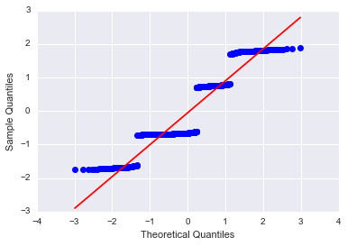

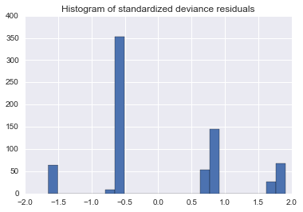

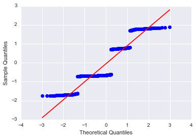

```python
# Make a residual quantile plot for the model of the interaction
fig_ans, ax_ans = plt.subplots()

resid_agesex = agesex_logit.resid_deviance.copy()
resid_std_ans = stats.zscore(resid_agesex)
ax_ans.hist(resid_std_ans, bins=25)
ax_ans.set_title('Histogram of standardized deviance residuals');
graphics.gofplots.qqplot(resid_agesex, line='r')
```

```python
# perform contrasts to test some hypotheses, namely:
# adult females were more likely to survive than adult males
# adult females were more likely to survive than elderly passengers
# children were more likely to survive than adult males
# children were more likely to survive than elderly passengers

# use previous age_class function from before
agesex_data['Age_class'] = age_data.apply(age_class,axis=1)

# create another function that creates an age/sex class
def sex_class(row):
    if row['Age_class'] == 'child':
        val = 'child'
    elif row['Age_class'] == 'adult':
        if row['Sex_male'] == 1:
            val = 'adult_male'
        else:
            val = 'adult_fem'
    else:
        val = 'senior'
    return val

agesex_data['Age_sex'] = agesex_data.apply(sex_class,axis=1)
#print agesex_data.head()

levels = [1,2,3,4]
contrast = Treatment(reference=0).code_without_intercept(levels)
print agesex_data.groupby('Age_sex')['Survived'].mean()
#print contrast.matrix

c_agesex = ols('Survived ~ C(Age_sex,Treatment)',data=agesex_data)
res_c_agesex = c_agesex.fit()
print(res_c_agesex.summary())
#print res_c_agesex.pvalues
```

```
Age_sex
adult_fem     0.760638
adult_male    0.176471
child         0.590361
senior        0.368932
Name: Survived, dtype: float64
                            OLS Regression Results
==============================================================================
Dep. Variable:               Survived   R-squared:                       0.259
Model:                            OLS   Adj. R-squared:                  0.255
Method:                 Least Squares   F-statistic:                     82.51
Date:                Sat, 29 Oct 2016   Prob (F-statistic):           8.36e-46
Time:                        15:06:29   Log-Likelihood:                -398.64
No. Observations:                 714   AIC:                             805.3
Df Residuals:                     710   BIC:                             823.6
Df Model:                           3
Covariance Type:            nonrobust
=======================================================================================================
                                          coef    std err          t      P>|t|      [95.0% Conf. Int.]
-------------------------------------------------------------------------------------------------------
Intercept                               0.7606      0.031     24.592      0.000         0.700     0.821
C(Age_sex, Treatment)[T.adult_male]    -0.5842      0.039    -15.156      0.000        -0.660    -0.508
C(Age_sex, Treatment)[T.child]         -0.1703      0.056     -3.047      0.002        -0.280    -0.061
C(Age_sex, Treatment)[T.senior]        -0.3917      0.052     -7.535      0.000        -0.494    -0.290
==============================================================================
Omnibus:                       27.266   Durbin-Watson:                   1.888
Prob(Omnibus):                  0.000   Jarque-Bera (JB):               20.228
Skew:                           0.311   Prob(JB):                     4.05e-05
Kurtosis:                       2.458   Cond. No.                         5.15
==============================================================================

Warnings:
[1] Standard Errors assume that the covariance matrix of the errors is correctly specified.
```

## Look at the influence of socioeconomic class on survivorship

```python
# Because both the dependent and independent variables for this are categorical, I will use a frequency
# table to determine whether (or not) there are significant differences in survivorship among the passenger classes

class_tab = pd.crosstab(index = titanic_df['Survived'],columns=titanic_df['Pclass'],margins=True)
class_tab.columns = ["First Class","Second Class","Third Class","RowTotal"]
class_tab.index = ["Died","Survived","ColTotal"]
print class_tab

prop_surv_class = class_tab / class_tab.ix["ColTotal"]
print prop_surv_class

# make a list containing the proportion of survivors in each class
class_surv = []
for i in prop_surv_class.columns:
    if i != 'RowTotal':
        class_surv.append(prop_surv_class[i][1])
class_surv = list(reversed(class_surv))
#print class_surv
```

```
          First Class  Second Class  Third Class  RowTotal
Died               80            97          372       549
Survived          136            87          119       342
ColTotal          216           184          491       891
          First Class  Second Class  Third Class  RowTotal
Died          0.37037      0.527174     0.757637  0.616162
Survived      0.62963      0.472826     0.242363  0.383838
ColTotal      1.00000      1.000000     1.000000  1.000000
```

```python
# Use a glm with a binomial distribution to model prob of survival based on passenger class (in this case
# assume class is a continuous variable)
titanic_df['Intercept'] = 1.0
class_train = titanic_df.columns[[2,12]]
class_logit = sm.GLM(titanic_df['Survived'], titanic_df[class_train], family=sm.families.Binomial()).fit()
print class_logit.summary()
#print class_logit.pvalues

# output odds ratios for continuous class model
print np.exp(class_logit.params)

# The following analysis is the categorical analogue of the analysis above... it seemed more interesting to consider class as
# a categorical variable for the purposes of analysis.
if False:
    # Create a dummy variable for the pclass variable
    dummy_ranks_class = pd.get_dummies(titanic_df['Pclass'],prefix='Pclass')
    dummy_ranks_class = dummy_ranks_class.astype(int)

    # Create new data set that joins the dummy variable to the relevant variables for the analysis
    cols_to_keep3 = ['Survived','Pclass','Intercept']
    class_data = titanic_df[cols_to_keep3].join(dummy_ranks_class.ix[:,'Pclass_2':])
    #print class_data.head()

    # Create another model where passenger class is a categorical variable
    class_train2 = class_data.columns[[2,3,4]]
    c_logit = sm.GLM(class_data['Survived'], class_data[class_train2], family=sm.families.Binomial()).fit()
    print c_logit.summary()

    # output odds ratios for categorical class model
    print np.exp(c_logit.params)
```

```
                 Generalized Linear Model Regression Results
==============================================================================
Dep. Variable:               Survived   No. Observations:                  891
Model:                            GLM   Df Residuals:                      889
Model Family:                Binomial   Df Model:                            1
Link Function:                  logit   Scale:                             1.0
Method:                          IRLS   Log-Likelihood:                -542.20
Date:                Sat, 29 Oct 2016   Deviance:                       1084.4
Time:                        15:06:36   Pearson chi2:                     890.
No. Iterations:                     6
==============================================================================
                 coef    std err          z      P>|z|      [95.0% Conf. Int.]
------------------------------------------------------------------------------
Pclass        -0.8501      0.087     -9.755      0.000        -1.021    -0.679
Intercept      1.4468      0.207      6.975      0.000         1.040     1.853
==============================================================================
Pclass       0.427369
Intercept    4.249450
dtype: float64
```

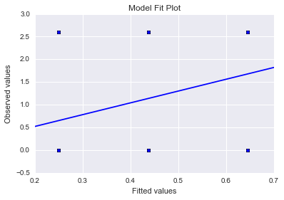

```python
# Print some diagnostic plots to assess model fit
nobs_class = class_logit.nobs

y_class = titanic_df['Survived']/titanic_df['Survived'].mean()
yhat_class = class_logit.mu
fig_class, ax_class = plt.subplots()
ax_class.scatter(yhat_class, y_class)
line_fit_class = sm.OLS(y_class, sm.add_constant(yhat_class, prepend=True)).fit()
abline_plot(model_results=line_fit_class,ax=ax_class)
ax_class.set_title('Model Fit Plot')
ax_class.set_ylabel('Observed values')
ax_class.set_xlabel('Fitted values')
```

```python
# take a look at things closer by looking at sex in addition to passenger class
class_sex_tab = pd.crosstab(index=titanic_df['Survived'],columns=[titanic_df['Pclass'],titanic_df['Sex']],margins = True)
print class_sex_tab

# Calculate the proportion of males and females that survived for each class
sex_prop_surv = class_sex_tab / class_sex_tab.ix["All"]
print sex_prop_surv
fem_prop = []
male_prop = []
for i in range(3):
    fem_prop.append(sex_prop_surv[3-i]['female'][1])
    male_prop.append(sex_prop_surv[3-i]['male'][1])
```

```
Pclass        1           2           3       All
Sex      female male female male female male
Survived
0             3   77      6   91     72  300  549
1            91   45     70   17     72   47  342
All          94  122     76  108    144  347  891
Pclass           1                   2                3                 All
Sex         female      male    female      male female      male
Survived
0         0.031915  0.631148  0.078947  0.842593    0.5  0.864553  0.616162
1         0.968085  0.368852  0.921053  0.157407    0.5  0.135447  0.383838
All       1.000000  1.000000  1.000000  1.000000    1.0  1.000000  1.000000
```

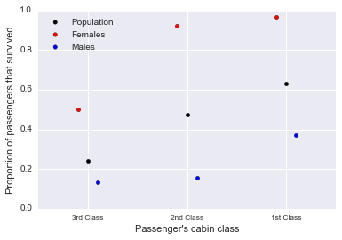

```python
# Create a figure to show probability of survival overall, and when one considers a passenger's sex
fig=plt.figure()
class_xs = [0,1,2]
fem_xs = [-0.1,0.9,1.9]
male_xs = [.1,1.1,2.1]
x_labels = ['3rd Class','2nd Class','1st Class']
plt.scatter(class_xs,class_surv,c='black',label='Population')
plt.scatter(fem_xs,fem_prop,label="Females",c='red')
plt.scatter(male_xs,male_prop,label="Males",c='blue')
#plt.setp(fig.get_xticklabels(),visible=True)
plt.xticks(range(len(class_surv)),x_labels,size='small')
plt.ylabel('Proportion of passengers that survived')
plt.xlabel("Passenger's cabin class")
plt.ylim([0,1])
plt.legend(loc='upper left')
plt.show()
```

```python
# Run a glm with a binomial distribution to model prob of survival based on passenger class and passenger sex (in this case
# assume class is a continuous variable)
cols_to_keep = ['Survived','Sex','Pclass']
sex_data = titanic_df[cols_to_keep].copy()
# Create a dummy variable for the sex variable
dummy_ranks_sex = pd.get_dummies(sex_data['Sex'],prefix='Sex')
dummy_ranks_sex = dummy_ranks_sex.astype(int)
#print dummy_ranks_sex.head()

# Add an intercept column so that the logistic regression estimates an intercept
sex_data['Intercept'] = 1.0

# Create new data set that joins the dummy variable to the relevant variables for the analysis
cols_to_keep4 = ['Survived','Pclass','Intercept']
sex_data = clean_age_df[cols_to_keep4].join(dummy_ranks_sex.ix[:,'Sex_male':])
#print sex_data.head()

sexclass_train = sex_data.columns[[1,2,3]]
sexclass_logit = logit(formula='Survived ~ Pclass + Sex_male + Pclass * Sex_male',data=sex_data).fit()
print sexclass_logit.summary()
print sexclass_logit.bic

print "The odds ratios are: \n", np.exp(sexclass_logit.params)
```

```
Optimization terminated successfully.
         Current function value: 0.454920
         Iterations 7
                           Logit Regression Results
==============================================================================
Dep. Variable:               Survived   No. Observations:                  714
Model:                          Logit   Df Residuals:                      710
Method:                           MLE   Df Model:                            3
Date:                Sun, 30 Oct 2016   Pseudo R-squ.:                  0.3265
Time:                        13:40:42   Log-Likelihood:                -324.81
converged:                       True   LL-Null:                       -482.26
                                        LLR p-value:                 5.956e-68
===================================================================================
                      coef    std err          z      P>|z|      [95.0% Conf. Int.]
-----------------------------------------------------------------------------------
Intercept           6.1052      0.852      7.163      0.000         4.435     7.776
Pclass             -2.0674      0.311     -6.655      0.000        -2.676    -1.459
Sex_male           -6.0503      0.908     -6.664      0.000        -7.830    -4.271
Pclass:Sex_male     1.4306      0.340      4.207      0.000         0.764     2.097
===================================================================================
675.909814997
The odds ratios are:
Intercept          448.199343
Pclass               0.126510
Sex_male             0.002357
Pclass:Sex_male      4.181031
dtype: float64
```

# Hypothesis 4

## Look at how age varies with class and sex

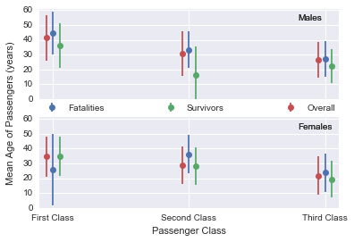

```python
# Exploratory plotting
groups = clean_age_df.groupby(['Sex','Survived','Pclass']).agg([np.mean,lambda x: np.std(x, ddof=1)])
groups2 = clean_age_df.groupby(['Sex','Pclass']).agg([np.mean,lambda x: np.std(x, ddof=1)])

#print groups['Age']
#print groups2['Age']
# Plot
fig, ax = plt.subplots(2,sharey=True,sharex=True)

markers =[ 'o','v']
for i in [0,1]:
    count = 0
    for j in ['male','female']:
        if i ==0:
            l = 'Fatalities'
        else:
            l = 'Survivors'
        ax[count].errorbar([0+i*0.05,1+i*0.05,2+i*0.05],groups['Age']['mean'][j][i],yerr=groups['Age']['<lambda>'][j][i].tolist(),linestyle='',marker="o",label=l)
        ax[count].text(1.8,53,j[:1].upper()+j[1:]+"s")
        count += 1

count = 0
for i in ['male','female']:
    ax[count].errorbar([0-0.05,1-0.05,2-0.05],groups2['Age']['mean'][i],yerr=groups2['Age']['<lambda>'][i].tolist(),linestyle='',marker="o",label="Overall")
    count += 1

x_axis=["First Class","Second Class","Third Class"]
plt.xticks(range(3),x_axis)
plt.xlim([-0.1,2.10])
plt.ylim([0,61])
plt.xlabel("Passenger Class")
plt.ylabel("Mean Age of Passengers (years)")
ax[1].yaxis.set_label_coords(-.08, 1.05)
plt.legend(bbox_to_anchor=(0., 1.02, 1., .102), loc=3,
           ncol=3, mode="expand", borderaxespad=0.)

plt.show()
```

## Now get ready for more complex analysis...

```python
# Create a dummy variable for the sex variable
#dummy_ranks_class = pd.get_dummies(clean_age_df['Pclass'],prefix='Pclass')
#dummy_ranks_class = dummy_ranks_class.astype(int)
#print dummy_ranks_class.head()

# Add the intercept to the starting clean df
clean_age_df['Intercept'] = 1.0
#print clean_age_df.head()

# Create new data set that joins the dummy variable to the relevant variables for the analysis and also sex (just in case)
cols_to_keep2 = ['Survived','Age','Intercept','Pclass']
#ageclass_data = clean_age_df[cols_to_keep2].join(dummy_ranks_class.ix[:,'Pclass_2':])
#print ageclass_data.head()

ageclasssex_data = clean_age_df[cols_to_keep2].join(dummy_ranks_sex.ix[:,'Sex_male':])
#print ageclasssex_data.head()
```

```python
# Run a full logistic regression model including the interaction between age, sex and class
full_ageclasssex = logit(formula='Survived~Age+Sex_male+Pclass+Age*Pclass+Age*Sex_male+Sex_male*Pclass+Age*Sex_male*Pclass',data=ageclasssex_data).fit()
#full_ageclasssex = logit(formula='Survived~Age+Sex_male+Pclass_2+Pclass_3+Age*Pclass_2+Age*Pclass_3+Age*Sex_male+Sex_male*Pclass_2+Sex_male*Pclass_3+Age*Sex_male*Pclass_2+Age*Sex_male*Pclass_3',data=ageclasssex_data).fit()
print '\n Full model'
print full_ageclasssex.summary()

# output odds ratios for this full model
print np.exp(full_ageclasssex.params)
# get AIC score
print full_ageclasssex.bic

#Print some diagnostic plots to assess model fit
if False:
    nobs_ans = result_ans.nobs
    y_asc = ageclasssex_data['Survived']/ageclasssex_data['Survived'].mean()
    yhat_asc = result_ans.mu
    fig_asc, ax_asc = plt.subplots()
    ax_asc.scatter(yhat_asc, y_asc)
    line_fit_asc = sm.OLS(y_asc, sm.add_constant(yhat_asc, prepend=True)).fit()
    abline_plot(model_results=line_fit_asc,ax=ax_asc)
    ax_asc.set_title('Model Fit Plot')
    ax_asc.set_ylabel('Observed values')
    ax_asc.set_xlabel('Fitted values')
```

```
Optimization terminated successfully.
         Current function value: 0.434771
         Iterations 8

 Full model
                           Logit Regression Results
==============================================================================
Dep. Variable:               Survived   No. Observations:                  714
Model:                          Logit   Df Residuals:                      706
Method:                           MLE   Df Model:                            7
Date:                Sun, 30 Oct 2016   Pseudo R-squ.:                  0.3563
Time:                        10:44:47   Log-Likelihood:                -310.43
converged:                       True   LL-Null:                       -482.26
                                        LLR p-value:                 2.799e-70
=======================================================================================
                          coef    std err          z      P>|z|      [95.0% Conf. Int.]
---------------------------------------------------------------------------------------
Intercept               5.5897      2.211      2.529      0.011         1.257     9.922
Age                     0.0274      0.067      0.410      0.682        -0.103     0.158
Sex_male               -3.9937      2.372     -1.683      0.092        -8.643     0.656
Pclass                 -1.6801      0.782     -2.149      0.032        -3.212    -0.148
Age:Pclass             -0.0190      0.024     -0.775      0.438        -0.067     0.029
Age:Sex_male           -0.0549      0.070     -0.780      0.435        -0.193     0.083
Sex_male:Pclass         0.9712      0.860      1.129      0.259        -0.714     2.657
Age:Sex_male:Pclass     0.0093      0.027      0.346      0.730        -0.043     0.062
=======================================================================================
Intercept              267.647165
Age                      1.027728
Sex_male                 0.018431
Pclass                   0.186355
Age:Pclass               0.981212
Age:Sex_male             0.946535
Sex_male:Pclass          2.641056
Age:Sex_male:Pclass      1.009331
dtype: float64
673.420046129
```

```python
# Reduced model without 3-way interaction terms
red_mod1 = logit(formula='Survived~Age+Sex_male+Pclass+Age*Pclass+Age*Sex_male+Sex_male*Pclass',data=ageclasssex_data).fit()
if True:
    print '\n Reduced model 1'
    print red_mod1.summary()
    print red_mod1.bic

# Start reducing 2-way interaction terms
red_mod2 = logit(formula='Survived~Age+Sex_male+Pclass+Age*Sex_male+Sex_male*Pclass',data=ageclasssex_data).fit()
if True:
    print '\n Reduced model 2'
    print red_mod2.summary()
    print red_mod2.bic

# Keep on reducing
red_mod3 = logit(formula='Survived~Age+Sex_male+Pclass+Sex_male*Pclass',data=ageclasssex_data).fit()
if True:
    print '\n Reduced model 3'
    print red_mod3.summary()
    print red_mod3.bic
```

```
Optimization terminated successfully.
         Current function value: 0.434856
         Iterations 7

 Reduced model 1
                           Logit Regression Results
==============================================================================
Dep. Variable:               Survived   No. Observations:                  714
Model:                          Logit   Df Residuals:                      707
Method:                           MLE   Df Model:                            6
Date:                Sun, 30 Oct 2016   Pseudo R-squ.:                  0.3562
Time:                        10:45:15   Log-Likelihood:                -310.49
converged:                       True   LL-Null:                       -482.26
                                        LLR p-value:                 3.756e-71
===================================================================================
                      coef    std err          z      P>|z|      [95.0% Conf. Int.]
-----------------------------------------------------------------------------------
Intercept           6.2099      1.359      4.571      0.000         3.547     8.873
Age                 0.0069      0.030      0.228      0.819        -0.052     0.066
Sex_male           -4.7092      1.236     -3.811      0.000        -7.131    -2.287
Pclass             -1.9058      0.452     -4.218      0.000        -2.791    -1.020
Age:Pclass         -0.0113      0.010     -1.123      0.261        -0.031     0.008
Age:Sex_male       -0.0315      0.019     -1.674      0.094        -0.068     0.005
Sex_male:Pclass     1.2430      0.376      3.308      0.001         0.507     1.979
===================================================================================
666.970247264
Optimization terminated successfully.
         Current function value: 0.435738
         Iterations 7

 Reduced model 2
                           Logit Regression Results
==============================================================================
Dep. Variable:               Survived   No. Observations:                  714
Model:                          Logit   Df Residuals:                      708
Method:                           MLE   Df Model:                            5
Date:                Sun, 30 Oct 2016   Pseudo R-squ.:                  0.3549
Time:                        10:45:15   Log-Likelihood:                -311.12
converged:                       True   LL-Null:                       -482.26
                                        LLR p-value:                 8.029e-72
```

[output cut: 20 more lines]

```
Method:                           MLE   Df Model:                            4
Date:                Sun, 30 Oct 2016   Pseudo R-squ.:                  0.3531
Time:                        10:45:15   Log-Likelihood:                -311.99
converged:                       True   LL-Null:                       -482.26
                                        LLR p-value:                 1.943e-72
===================================================================================
                      coef    std err          z      P>|z|      [95.0% Conf. Int.]
-----------------------------------------------------------------------------------
Intercept           7.9644      0.969      8.218      0.000         6.065     9.864
Age                -0.0384      0.008     -4.859      0.000        -0.054    -0.023
Sex_male           -6.1155      0.929     -6.585      0.000        -7.936    -4.295
Pclass             -2.4102      0.329     -7.331      0.000        -3.055    -1.766
Sex_male:Pclass     1.4796      0.348      4.246      0.000         0.797     2.163
===================================================================================
656.840681087
```

There is a potentially intersting interaction here... Notably:

- between passenger sex and cabin class (but we have already looked into this...)

### Use a plot to understand what is going on with passengers in 2nd class

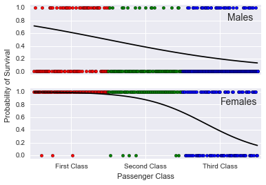

```python
# make a plot showing the two-way interaction between sex and cabin class
if True:
    fig, ax = plt.subplots(2,sharex=True,sharey=True)
    colors = ["red",'green','blue']
    c1 = 0
    c2 = 0
    males = ageclasssex_data[ageclasssex_data.Sex_male == 1].copy()
    females = ageclasssex_data[ageclasssex_data.Sex_male == 0].copy()
    male_preds = []
    female_preds = []
    xs = np.arange(1,4.01,.05)
    for j in xs:
        male_preds.append(1/(1+np.exp(-(red_mod3.params[0]+red_mod3.params[2]+red_mod3.params[3]*j+red_mod3.params[4]*j))))
        female_preds.append(1/(1+np.exp(-(red_mod3.params[0]+red_mod3.params[3]*j))))
    ax[0].plot(xs,male_preds,c="black")
    ax[1].plot(xs,female_preds,c="black",label="Predicted Outcome")
    ax[0].text(3.6,.8,"Males",fontsize=14)
    ax[1].text(3.5,.8,"Females",fontsize=14)
    for j in [1,2,3]:
        maleclass = males[males.Pclass == j].copy()
        femaleclass = females[females.Pclass == j].copy()
        malexs = np.arange(j,(j+1.01),1.01/float(len(maleclass)))
        femalexs = np.arange(j,(j+1.01),1.01/float(len(femaleclass)))
        ax[0].scatter(malexs,maleclass['Survived'],c=colors[j-1])
        ax[1].scatter(femalexs,femaleclass['Survived'],label=("%i class"%j),c=colors[j-1])
    plt.ylim([-0.05,1.05])
    plt.xlim([0.95,4.05])
    plt.xlabel("Passenger Class")
    plt.ylabel("Probability of Survival")
    x_axis=["First Class","Second Class","Third Class"]
    ax[1].yaxis.set_label_coords(-.08, 1.05)
    plt.xticks([1.5,2.5,3.5],x_axis)
    #plt.legend(bbox_to_anchor=(0., 1.02, 1., .102), loc=3,ncol=2, mode="expand", borderaxespad=0.)
```

# Here end the relevant bits for the assignment, the rest is stuff that I thought about doing but couldn't properly motivate.

### First define a function to compute conditional probabilities.

```python
# This function will compute the conditional probability of an event A occurring given that an event B has occurred.

def bayes_prob(category1,cond1,category2,cond2,df=titanic_df):
    # Compute probability that category 1 has condition 1 (this is more so for error checking and is not included in the end calculation)
    prob_cat1_cond1 = df[df[category1] == cond1].count()[0] / float(df.count()[0])

    # Compute probability that category 2 has condition 2
    prob_cat2_cond2 = df[df[category2] == cond2].count()[0] / float(df.count()[0])

    # Compute the probability of category 1 having condition 1 and category 2 having condition 2
    prob_cat1cond1_cat2cond2 = df[(df[category1]==cond1) & (df[category2]==cond2)].count()[0] / float(df.count()[0])

    # Compute the conditional probability of P(cond1 | cond2) = P(cond1 & cond 2) / P(cond 2)
    return prob_cat1cond1_cat2cond2 / prob_cat2_cond2
```

```python
print 'The probability of someone from first class surviving the ill-fated voyage is: ',bayes_prob('Survived',1,'Pclass',1)
print 'The probability of someone from second class surviving the ill-fated voyage is: ',bayes_prob('Survived',1,'Pclass',2)
print 'The probability of someone from third class surviving the ill-fated voyage is: ',bayes_prob('Survived',1,'Pclass',3)
```

```
The probability of someone from first class surviving the ill-fated voyage is:  0.62962962963
The probability of someone from second class surviving the ill-fated voyage is:  0.472826086957
The probability of someone from third class surviving the ill-fated voyage is:  0.242362525458
```

## Look at the distribution of class rooms based on where people got on.

```python
print 'The probability that a passenger in a first class room was from Queenstown is: ', bayes_prob('Embarked','Q','Pclass',3)
print 'The probability that a passenger in a first class room was from Southampton is: ', bayes_prob('Embarked','S','Pclass',3)
print 'The probability that a passenger in a first class room was from Cherbourg is: ', bayes_prob('Embarked','C','Pclass',3)
print bayes_prob('Embarked','C','Pclass',1) + bayes_prob('Embarked','S','Pclass',1) + bayes_prob('Embarked','Q','Pclass',1)
```

[output not shown]

## Look at age distribution and point of embarkation

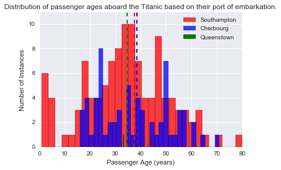

[figure not shown]

```python
cherbourg = titanic_df[titanic_df['Embarked']=='C'].copy()
cherbourg_ages = cherbourg.dropna()
queenstown = titanic_df[titanic_df['Embarked']=='Q'].copy()
queenstown_ages = queenstown.dropna()
southampton = titanic_df[titanic_df['Embarked']=='S'].copy()
southampton_ages = southampton.dropna()

mu_cher = cherbourg_ages['Age'].mean()
mu_queen = queenstown_ages['Age'].mean()
mu_south = southampton_ages['Age'].mean()

embark_classes = titanic_df.groupby(['Embarked','Pclass'])
#print embark_classes.head()
plt.hist(southampton_ages['Age'],bins=30,label='Southampton',color='r',alpha=.75)
plt.hist(cherbourg_ages['Age'],bins=30,label='Cherbourg',color='b',alpha=.75)
plt.hist(queenstown_ages['Age'],bins=30,label='Queenstown',color='g')
plt.axvline(mu_cher, color='r', linestyle='dashed', linewidth=2)
plt.axvline(mu_queen, color='b', linestyle='dashed', linewidth=2)
plt.axvline(mu_south, color='g', linestyle='dashed', linewidth=2)
plt.legend(loc='upper right')
plt.ylabel('Number of Instances')
plt.xlabel('Passenger Age (years)')
plt.title('Distribution of passenger ages aboard the Titanic based on their port of embarkation.')
plt.ylim([0,11])
plt.show()

plt.hist(southampton['Pclass'],bins=3,label='Southampton',color='r')
plt.hist(cherbourg['Pclass'],bins=3,label='Cherbourg',color='b')
plt.hist(queenstown['Pclass'],bins=3,label='Queenstown',color='g')
plt.legend(loc='upper left')
plt.ylabel('Number of Instances')
plt.xlabel('Passenger Age (years)')
plt.title('Distribution of passenger ages aboard the Titanic based on their port of embarkation.')
#plt.ylim([0,11])
plt.show()
```